# MICB425 Portfolio - Microbial Ecological Genomics: From Genomes to Biomes, Spring 2018

Jinsong, Tony, Yan, 18752148

Version 1.0 (January 19, 2018)

# Module 01

Reserve the first level headings (#) for the start of a new Module. This will help to organize your portfolio in an intuitive fashion.

## Module 01 portfolio check

The first of your second level headers (##) is to be used for the portfolio content checks. The Module 01 portfolio check has been built for you directly into this template, but will also be available as a stand-alone markdown document available on the MICB425 GitHub so that you know what is required in each module section in your portfolio. The completion status and comments will be filled in by the instructors during portfolio checks when your current portfolios are pulled from GitHub.

- Installation check
  - Completion status:
  - Comments:
- Portfolio repo setup
  - Completion status:
  - Comments:
- RMarkdown Pretty html Challenge
  - Completion status:
  - Comments:
- Evidence worksheet_01
  - Completion status:
  - Comments:
- Evidence worksheet_02
  - Completion status:
  - Comments:
- Evidence worksheet_03
  - Completion status:
  - Comments:
- Problem Set_01
  - Completion status:
  - Comments:
- Problem Set_02
  - Completion status:
  - Comments:
- Writing assessment_01
  - Completion status:
  - Comments:
- Additional Readings
  - Completion status:
  - Comments

## Data science Friday

The remaining second level headers (##) are for separating data science Friday, regular course, and project content. In this module, you will only need to include data science Friday and regular course content; projects will come later in the course.

## Installation check (Data Science Friday 1)

Use this space to include your installation screenshots.

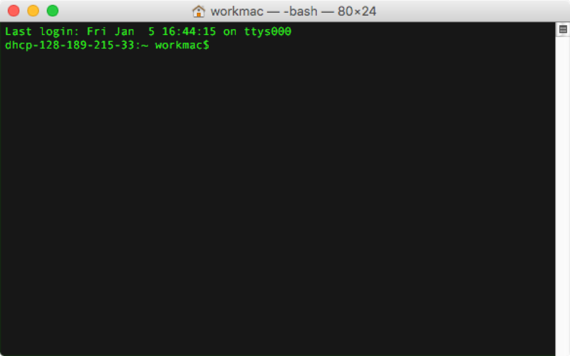

Terminal

[figure not shown]

Rstudio

[figure not shown]

Github

### Portfolio repo setup (Data Science Friday 2)

Detail the code you used to create, initialize, and push your portfolio repo to GitHub. This will be helpful as you will need to repeat many of these steps to update your porfolio throughout the course.

**To intialize github account from github:**

stndin: git config –global user.name “Your Name”

stndin: git config –global user.email “youremail@email.com”

**To clone from github master:**

stndin: git clone [git url]

**To pull down from github master:**

stndin: git fetch

stndin: git pull

**To push to github from origin master:**

stndin: git add .

stndin: git commit -m “commit message here”

stndin: git status

stndin: git push

## Origins and Earth Systems

### Evidence Worksheet for “Prokaryotes: The Unseen Majority”

### Learning Objectives

Describe the numerical abundance of microbial life in relation to ecology and biogeochemistry of Earth systems.

### General Questions

#### What were the main questions being asked?

(Answer): How many prokaryotes are there in the world? How abundant are they relative to their ecosystems? To what extent do they participate in the global carbon cycling (and nitrogen, phosphorus, etc)?__

#### What were the primary methodological approaches used?

(Answer): Estimation Methods: Water: Sediment density/mL Soil: Estimated from unpublished field studies. Subsurface: Ground water sample estimations,as well as estimations from porosity of the ground and amount of space that prokaryotes occupied in pores. Microbiota: Estimation from microbiota density and the population sizes of animals. Leaves/Plants: Estimates are made from leaf area estimated by leaf area index. Carbon estimations: Total organisms multiplied by 1/2 dry weight.

#### Summarize the main results or findings.

(Answer): Essentially nutrient cycle estimations for a variety of environments. Total cellular carbon: 350-550 Pg of C Total cells: 4-6 x 10^30 Total cellular nitrogen: 85-130 Pg N Total cellular phosphorus: 9-14 Pg P Total prokaryotic microorganisms: Open Ocean: 1.2 x 10^29 Soil: 2.6 x 10^29 ocean/terrestrial subsurface: 3.5 x 10^30 0.25-2.5 x 10^30 Report statistics about how many prokaryotes are located in different environments.

#### Do new questions arise from the results?

(Answer): How does the abundance of the prokaryotes in these environments play a role in the total metabolic potential in their ecosystem? How did the authors compile their calculations into their finalized findings, why did they use the assumptions that they did in doing so? How can the authors be sure that their estimations are accurate and precise? Since they have no discrete controls or replicates? What were the statistical methods used to standardize across environments, between different sampling methodologies?

#### Were there any specific challenges or advantages in understanding the paper (e.g. did the authors provide sufficient background information to understand experimental logic, were methods explained adequately, were any specific assumptions made, were conclusions justified based on the evidence, were the figures or tables useful and easy to understand)?

(Answer): Methods were not fully explained to a point of possible replication of their estimates. Authors did not provide enough justification to use the assumptions that they did, and does not show how their assumptions may affect their estimates in one way or another.

## [Whitman *et al* 1998](https://www.ncbi.nlm.nih.gov/pmc/articles/PMC33863/)

## Problem set 01

#### Learning objectives:

Describe the numerical abundance of microbial life in relation to the ecology and biogeochemistry of Earth systems.

#### Specific questions:

- What are the primary prokaryotic habitats on Earth and how do they vary with respect to their capacity to support life? Provide a breakdown of total cell abundance for each primary habitat from the tables provided in the text.

(Answer): Marine environments (1.181x10^29) including polar water-ice interfaces, Soil (2.556x10^29), subsurface marine sediments (3.8x10^30), and microbiota.

- What is the estimated prokaryotic cell abundance in the upper 200 m of the ocean and what fraction of this biomass is represented by marine cyanobacterium including Prochlorococcus? What is the significance of this ratio with respect to carbon cycling in the ocean and the atmospheric composition of the Earth?

- What is the difference between an autotroph, heterotroph, and a lithotroph based on information provided in the text?

(Answer): Autotroph: Fixes carbon from carbon dioxide gas. Heterotroph: Uses carbon from organic compounds. Lithotroph: Uses inorganic substances (like minerals) to obtain reducing agents.

- Based on information provided in the text and your knowledge of geography what is the deepest habitat capable of supporting prokaryotic life? What is the primary limiting factor at this depth?

(Answer): Deep habitats supporting life, subsurface separated into terrestrial and marine. Temperature is limiting factor at very high depths in Mariana Trench (10.9km).

- Based on information provided in the text your knowledge of geography what is the highest habitat capable of supporting prokaryotic life? What is the primary limiting factor at this height?

(Answer): Qualities of air and atmosphere at that environment (Mt Everest 8.8km) also affects growth capabilities.

- Based on estimates of prokaryotic habitat limitation, what is the vertical distance of the Earth’s biosphere measured in km?

(Answer): 24km from the highest point to the lowester point on Earth represents the general biosphere.

- How was annual cellular production of prokaryotes described in Table 7 column four determined? (Provide an example of the calculation)

(Answer): Population x turnover/yr = cells/yr. e.g. marine heteros -> [3.6x10^28 cells x 365 days]/16 turnovers = 8.2x10^29 cells/yr. Virus affect growth and turnover rate and may contain metabolic assessory genes that can reprogram cells metabolically.

- What is the relationship between carbon content, carbon assimilation efficiency and turnover rates in the upper 200m of the ocean? Why does this vary with depth in the ocean and between terrestrial and marine habitats?

(Answer): Carbon Efficiency = 20% 5-20fg C/cell 10x10^-30 pg/Cell (3.6x10^28 Cells)x(10x10^-30 pg/cell)= 0.72 Pg carbonin marine heteros. 4x0.72= 2.88 Pg/yr of C. 51 Pg C/yr w/ 85% consumed = 43 Pg C/yr (43 Pg C/yr)/(2.88 Pg/yr) = 14.9, 1 turnover every 24.5 days.

- How were the frequency numbers for four simultaneous mutations in shared genes determined for marine heterotrophs and marine autotrophs given an average mutation rate of 4 x 10<sup>-7</sup> per DNA replication? (Provide an example of the calculation with units. Hint: cell and generation cancel out)

(Answer): (4x10^-7 mutations/generation)^4 (simultaneous mutations) = 2.56x10^26 mutations/generation. 3.6x10^28 cells and 365/16=22.8 turnovers/yr. (3.6x10^28 x 22.8 = 8.2x10^29 Cells/yr x 2.56x10^-26 mutations/generation) = 2.1x10^4 mutations/yr.

- Given the large population size and high mutation rate of prokaryotic cells, what are the implications with respect to genetic diversity and adaptive potential? Are point mutations the only way in which microbial genomes diversify and adapt?

(Answer): Microbial genomes are horizontally trasferrable, indicating that a higher population size and population diversity will make the community as a whole, more dynamic and flexible to change. When under selection pressure due to a sudden drastic environment shift, microbial genetic diversity and HGT mechanisms ensure that genes necessary for fitness (selected from the few species that may possess them) is passed around the community quickly.

- What relationships can be inferred between prokaryotic abundance, diversity, and metabolic potential based on the information provided in the text?

(Answer): Prokaryotic abundance corresponds more towards the magnitude of metabolic activity in an environment, characterizing the total capacity for the ecosystem to undergo biochemical reactions. Prokaryotic species diversity is logarithmically related to metabolic diversity of the environment, where a greater species diversity contributes to a more diverse reaction sets that could potentially take place, up to an extent where eventually greater species diversity will result in metabolic redundancy.

# Pretty_html (Data Science Friday 3)

### *Tony Yan (18752148)*

### *version 1/24/2018*

- R Markdown PDF Challenge
  - Challenge Goals
    - Here’s a header!
    - Table Time

# R Markdown PDF Challenge

The following assignment is an exercise for the reproduction of this .html document using the RStudio and RMarkdown tools we’ve shown you in class. Hopefully by the end of this, you won’t feel at all the way this poor PhD student does. We’re here to help, and when it comes to R, the internet is a really valuable resource. This open-source program has all kinds of tutorials online.

[figure not shown]

http://phdcomics.com/ Comic posted 1-17-2018

## Challenge Goals

The goal of this R Markdown html challenge is to give you an opportunity to play with a bunch of different RMarkdown formatting. Consider it a chance to flex your RMarkdown muscles. Your goal is to write your own RMarkdown that rebuilds this html document as close to the original as possible. So, yes, this means you get to copy my irreverant tone exactly in your own Markdowns. It’s a little window into my psyche. Enjoy =)

**hint: go to the [PhD Comics website](http://phdcomics.com/) to see if you can find the image above**

*If you can’t find that exact image, just find a comparable image from the PhD Comics website and include it in your markdown*

### Here’s a header!

Let’s be honest, this header is a little arbitrary. But show me that you can reproduce headers with different levels please. This is a level 3 header, for your reference (you can most easily tell this from the table of contents).

#### Another Header, now with maths

Perhaps you’re already really confused by the whole markdown thing. Maybe you’re so confused that you’ve forgotton how to add. Never fear! A calculator R is here:

```r
1231521+12341556280987
```

```
## [1] 1.234156e+13
```

### Table Time

Or maybe, after you’ve added those numbers, you feel like it’s about time for a table! I’m going to leave all the guts of the coding here so you can see how libraries (R packages) are loaded into R (more on that later). It’s not terribly pretty, but it hints at how R works and how you will use it in the future. The summary function used below is a nice data exploration function that you may use in the <sup>future</sup>.

```r
library(knitr)
kable(summary(cars),caption="I made this table with kable in the knitr package library")
```

I made this table with kable in the knitr package library

|  | speed | dist |
| --- | --- | --- |
|  | Min. : 4.0 | Min. : 2.00 |
|  | 1st Qu.:12.0 | 1st Qu.: 26.00 |
|  | Median :15.0 | Median : 36.00 |
|  | Mean :15.4 | Mean : 42.98 |
|  | 3rd Qu.:19.0 | 3rd Qu.: 56.00 |
|  | Max. :25.0 | Max. :120.00 |

And now you’ve almost finished your first RMarkdown! Feeling excited? We are! In fact, we’re so excited that maybe we need a big finale eh? Here’s ours! Include a fun gif of your choice!

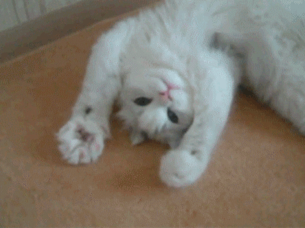

## Evidence Worksheet_02 “Life and the Evolution of Earth’s Atmosphere”

#### Learning objectives:

Comment on the emergence of microbial life and the evolution of Earth systems

- Indicate the key events in the evolution of Earth systems at each approximate moment in the time series. If times need to be adjusted or added to the timeline to fully account for the development of Earth systems, please do so.
  - 4.6 billion years ago: Formation of Earth and the moon from the proposed collision between proto-Earth and proto-moon. Caused formation of Earth’s early atmosphere, comprised of mostly methane, ammonia, hydrogen, nitrogen, and water vapor.
  - 4.2 billion years ago: Earliest evidence for life. Late heavy bombardment.
  - 3.8 billion years ago: Earliest signs of photosynthesis. Rubisco discovered. Early formation of oceans.
  - 3.5 billion years ago: Earliest common ancestor between bacteria and archea split. Earliest fossils of bacteria and archaea dates to here. Anoxic photogenesis from microfossils.
  - 3.0 billion years ago: First large asteroid impact on Earth. Photosynthetic cyanobacteria evolve. Increase in oxygenation of the atomosphere. First global glaciation.
  - 2.7 billion years ago: Early evidence of eukaryotes discovered by association with sterols. Saturation of ocean with oxygen, significant oxygen presence in atmosphere. Early life on land.
  - 2.2 billion years ago: Earliest known eukaryotic fossils.
  - 2.1 billion years ago: Lesser early supercontinents form
  - 1.8 billion years ago: Stablization of second continental mass. Early evidence of oxidation corresponding to rise in oxygen levels in atmosphere. Complex eukaryotes evolved.
  - 1.3 billion years ago: Earliest evidence of sexually reproducing organisms from single cell eukarya. Early evidence for predation.
  - 1.0 billion years ago: First major ice age, glaciation disrupts carbon cycle.
  - 550 million years ago: First forms of skeletal life. End of “snowball Earth”, earliest arthropods and fungi. Cambrian explosion, sees first emergence of many vertebrates.
  - 350 million years ago: Evolution diversifies species of vertebrates. Further increase in oxygenation of atomosphere due to emergence of woody land plants. Pangea emerges.
  - 200 million years ago: Dinosaurs! Followed by Permian extinction, loss of 95% species diversity.
  - 60 million years ago: Evolution of mammals and other vertebrates. Dramatic global warming followed by ice age.
  - 2 million years ago - today: Evolution of humans and mammals post ice age.
- Describe the dominant physical and chemical characteristics of Earth systems at the following waypoints:
  - Hadea: Ball of molten atmosphere and molten crust.
  - Archean: Early oxgenation of the atmosphere with photosynthesis prokaryotes. High concentration of hydrocarbons in atmosphere. Sun was 30% less luminous.
  - Precambrian: End of snowball Earth. Species see explosion in diversity. Atmosphere and geological properties support different metabolic processes and nutrient cycling at the most basic level.
  - Proterozoic: Plants and animals differentiate, causing environmental conditions to support autotrophs and heterotrophs. Greater oxygenation of the atmosphere to support multicellular respiration.
  - Phanerozoic: Global warming and cooling cycles between ice age and warming. Causing bloom in species diversity followed by mass extinctions. Atmosphere and geologic conditions become rich in organic nutrients quickly giving birth to new species when the niche is right. Emergence of complex carbon, oxygen, nitrogen, phosphorous, and sulfur cycling.

## Problem set 02

#### Learning objectives:

Discuss the role of microbial diversity and formation of coupled metabolism in driving global biogeochemical cycles.

#### General questions:

- What are the primary geophysical and biogeochemical processes that create and sustain conditions for life on Earth? How do abiotic versus biotic processes vary with respect to matter and energy transformation and how are they interconnected?

(Answer): Volcanism and rock weathering and plate tectonics helped to shape the geological conditions for life. Supplies and sinks carbon dioxide and sulfur cycling.

- Why is Earth’s redox state considered an emergent property?

(Answer): Life on earth cannot be attributed to a single factor, therefore, the entire system ought to be examined as a whole. Where the whole is more than a sum of its parts. Many organisms needs to be coupled to other organisms where one biological process can only occur when linked to another.

- How do reversible electron transfer reactions give rise to element and nutrient cycles at different ecological scales? What strategies do microbes use to overcome thermodynamic barriers to reversible electron flow?

(Answer): Thermodynamics determines favorable flow of electrons that allows biological reactions to occur spontaneously. Each reaction is spontaneous only in the environment which it occurs in, and in order to revert the reaction, the environmental conditions need to change for the reverse reaction to be spontaneous. This causes nutrients to be generally localized, preventing a global even distribution of nutrients in all environments. This builds a sort of “economy of scale” within microbial communities. The scale which thermodynamic events can occur is therefore dependent on the energetic favorability of certain organisms/communities of organisms to take place versus others.

- Using information provided in the text, describe how the nitrogen cycle partitions between different redox “niches” and microbial groups. Is there a relationship between the nitrogen cycle and climate change?

(Answer): Microbes generally form distirbuted groups that carry out certain metabolic functions within their communities. These groups specialized into niches that carry out only one reaction within the nitrogen cycle. For example a group of organisms that reduces N2 gas to ammonium, and the reverse reaction of oxidizing ammonium are carried out by niches of other communities. Nitrous oxide is a potent greenhouse gas which can be pushed towards with Le Chatelier’s principle on a population/community scale.

- What is the relationship between microbial diversity and metabolic diversity and how does this relate to the discovery of new protein families from microbial community genomes?

(Answer): Much of metabolic diversity arises from the adaptation of existing metabolic pathways due to great correlation and co-evolution between microbial species. Microorganisms utilize available resources from their environment in the most thermaldynamically favorable means, which often times result in modulation and altered implementation of existing pathways and enzymes, rather than evolving entirely novel mechanisms. This can be done over time through horizontal gene transfers between species, and emergence of new species from existing ones based on genetic differentiation. As species diversity increases, metabolic diversity increases logarithmically, meaning fewer and fewer new proteins without homologs are discovered for every species discovered.

- On what basis do the authors consider microbes the guardians of metabolism?

(Answer): The Authors claim that due to horizontal gene transfer and the general conserved nature of genes that encode metabolic pathway enzymes, microbes that may survive a certain selection pressure can go on to preserve their metabolic capabilities and transfer them to the overall environment. Regardless of what the selection pressures are or how strong they are, certain species will always survive, and they serve as a sort of noah’s ark for metabolic genes so that the environment may continue to cycle nutrients.

## Working with Data in R (Data science Friday 4)

### *Tony Yan (18752148)*

### *version 1/31/2018*

### Exercise 1:

*We have another data table we will be using in up-coming DS Fridays, Saanich.OTU.txt. Import this data as a named object with the correct parameters in R.*

```r
read.table(file="Saanich.metadata.txt", header=TRUE, row.names=1, sep="\t", na.strings=c("NAN", "NA", "."))
```

```
##              Depth_m   O2_uM PO4_uM SiO2_uM NO3_uM NH4_uM Std_NH4_uM
## SI072_S3_010      10 216.667  0.520  20.672  1.793 0.4080     0.0084
## SI072_S3_020      20 159.672  1.817  32.888 13.736 2.6551     0.0044
## SI072_S3_040      40 141.778  2.244  38.980 22.013 1.3007     0.0087
## SI072_S3_060      60  97.894  2.598  47.335 28.434 0.2652     0.0047
## SI072_S3_075      75  44.978  3.190  60.986 30.604 0.1281     0.0227
## SI072_S3_085      85  25.807  3.745  70.963 28.731 0.1780     0.0070
## SI072_S3_090      90  27.011  3.934  67.897 26.780 0.1307     0.0054
## SI072_S3_097      97  34.436  3.942  67.645 26.248 0.1371     0.0061
## SI072_S3_100     100  38.012  3.672  69.062 26.400 0.1344     0.0092
## SI072_S3_110     110  27.557  3.965  69.577 24.355 0.1046     0.0252
## SI072_S3_120     120  32.354  4.090  64.383 21.302 0.1782     0.0100
## SI072_S3_135     135  20.446  4.342  70.321 15.917 0.1296     0.0166
## SI072_S3_150     150   0.000  4.988  70.780  5.278 2.1754     0.0293
## SI072_S3_165     165   0.000  5.599  62.580  0.000 4.7095     0.2112
## SI072_S3_185     185   0.000  5.974  64.763  0.000 6.4038     0.4384
## SI072_S3_200     200   0.000  6.298  66.200  0.000 7.3582     0.2816
##              NO2_uM Std_NO2_uM  H2S_uM Std_H2S_uM Cells.ml N2O_nM
## SI072_S3_010 0.1275     0.0088  0.0000     0.0000       NA  0.849
## SI072_S3_020 0.4938     0.0017  0.0000     0.0000       NA 13.199
## SI072_S3_040 0.3775     0.0052  0.0000     0.0000       NA 12.829
## SI072_S3_060 0.0471     0.0245  0.0000     0.0000       NA 12.306
## SI072_S3_075 0.0532     0.0052  0.0000     0.0000       NA 13.896
## SI072_S3_085 0.0966     0.0105  0.0000     0.0000       NA 12.959
## SI072_S3_090 0.0186     0.0192  0.0000     0.0000       NA 15.551
## SI072_S3_097 0.0297     0.0105  0.0000     0.0000       NA 18.682
## SI072_S3_100 0.0817     0.0105  0.0000     0.0000       NA 18.087
## SI072_S3_110 0.0619     0.0105  0.0000     0.0000       NA 15.843
## SI072_S3_120 0.0978     0.0018  0.0000     0.0000       NA 16.304
## SI072_S3_135 0.0706     0.0018  0.0000     0.0000       NA 12.909
## SI072_S3_150 0.1127     0.0018  0.0000     0.0000       NA 11.815
## SI072_S3_165 0.0805     0.0053  3.5027     0.0423       NA  6.310
## SI072_S3_185 0.0211     0.0158 11.6470     0.0827       NA  0.000
## SI072_S3_200 0.0000     0.0000 17.9867     0.0006       NA  0.000
##              Std_N2O_nM   CH4_nM Std_CH4_nM Temperature_C
## SI072_S3_010      0.114 1030.478      3.070        12.854
## SI072_S3_020      0.000   29.012      0.000        11.005
## SI072_S3_040      1.509   37.146      2.695         9.536
## SI072_S3_060      0.524   36.501      3.521         8.540
## SI072_S3_075      1.417   24.013      0.435         8.480
```

[output cut: 30 more lines]

```
## SI072_S3_020       28.763    21.923
## SI072_S3_040       29.352    22.619
## SI072_S3_060       30.115    23.365
## SI072_S3_075       30.551    23.714
## SI072_S3_085       30.745    23.858
## SI072_S3_090       30.803    23.895
## SI072_S3_097       30.838    23.915
## SI072_S3_100       30.872    23.933
## SI072_S3_110       30.932    23.977
## SI072_S3_120       31.007    24.026
## SI072_S3_135       31.088    24.076
## SI072_S3_150       31.164    24.118
## SI072_S3_165       31.197    24.138
## SI072_S3_185       31.231    24.157
## SI072_S3_200       31.248    24.167
```

```r
Saanich_metadata = read.table(file="Saanich.metadata.txt", header=TRUE, row.names=1, sep="\t", na.strings=c("NAN", "NA", "."))
```

### Exercise 2:

*Using dplyr, find at what depth(s) methane (CH4) is above 100 nM while temperature is below 10 °C. Print out a table showing only the depth, methane, and temperature data.*

```r
library(dplyr)
select(Saanich_metadata, starts_with("CH4"))
```

```
##                CH4_nM
## SI072_S3_010 1030.478
## SI072_S3_020   29.012
## SI072_S3_040   37.146
## SI072_S3_060   36.501
## SI072_S3_075   24.013
## SI072_S3_085    7.376
## SI072_S3_090    4.190
## SI072_S3_097    3.991
## SI072_S3_100    3.231
## SI072_S3_110    3.633
## SI072_S3_120    3.463
## SI072_S3_135    4.815
## SI072_S3_150    8.323
## SI072_S3_165   23.831
## SI072_S3_185  310.068
## SI072_S3_200  774.034
```

```r
filter(Saanich_metadata, CH4_nM > 100 & Temperature_C < 10) %>% select(Depth_m)
```

```
##   Depth_m
## 1     185
## 2     200
```

### Exercise 3:

*Convert all variables that are in nM to μM. Output a table showing only the original nM and converted μM variables.*

```r
library(dplyr)

select(Saanich_metadata, ends_with("nM")) %>%
  mutate(N2O_uM = N2O_nM/1000) %>%
  mutate(Std_N2O_uM = Std_N2O_nM/1000) %>%
  mutate(CH4_uM = CH4_nM/1000) %>%
  mutate(Std_CH4_uM = Std_CH4_nM/1000)
```

```
##    N2O_nM Std_N2O_nM   CH4_nM Std_CH4_nM   N2O_uM Std_N2O_uM   CH4_uM
## 1   0.849      0.114 1030.478      3.070 0.000849   0.000114 1.030478
## 2  13.199      0.000   29.012      0.000 0.013199   0.000000 0.029012
## 3  12.829      1.509   37.146      2.695 0.012829   0.001509 0.037146
## 4  12.306      0.524   36.501      3.521 0.012306   0.000524 0.036501
## 5  13.896      1.417   24.013      0.435 0.013896   0.001417 0.024013
## 6  12.959      0.955    7.376      0.029 0.012959   0.000955 0.007376
## 7  15.551      1.417    4.190      0.159 0.015551   0.001417 0.004190
## 8  18.682      1.628    3.991      0.759 0.018682   0.001628 0.003991
## 9  18.087      1.275    3.231      0.392 0.018087   0.001275 0.003231
## 10 15.843      1.953    3.633      0.127 0.015843   0.001953 0.003633
## 11 16.304      1.085    3.463      0.519 0.016304   0.001085 0.003463
## 12 12.909      2.577    4.815      0.658 0.012909   0.002577 0.004815
## 13 11.815      0.000    8.323      0.000 0.011815   0.000000 0.008323
## 14  6.310      0.732   23.831      2.291 0.006310   0.000732 0.023831
```

[output cut: 19 more lines]

## Plotting data in R (Data Science Friday 5)

### version February 08, 2018

### Exercise 1: Plot another nutrient of your choice against depth. Change the points to be purple triangles.

```r
library(tidyverse)
```

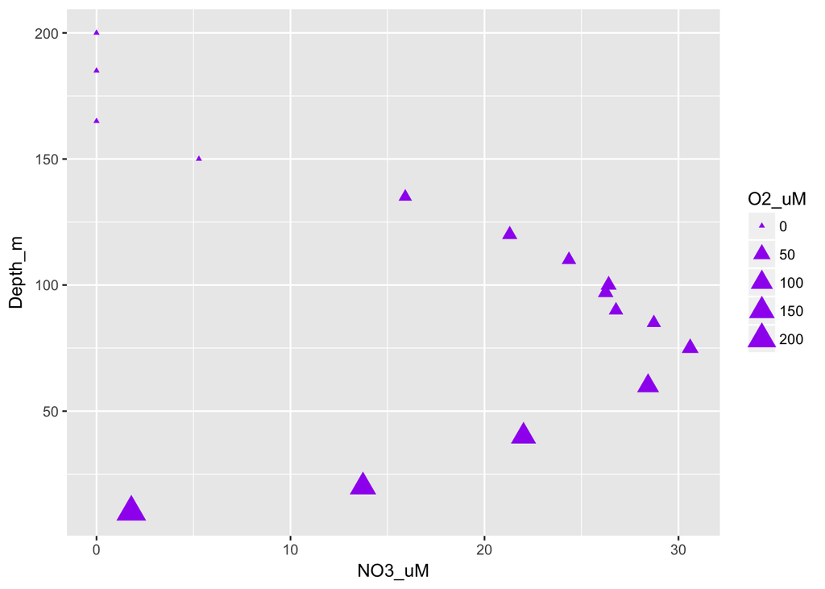

```r
library(phyloseq)

ggplot(Saanich_metadata, aes(x=NO3_uM, y=Depth_m, size=O2_uM)) +
  geom_point(color="purple", shape=17)
```

### Excercise 2: Using diplyr, convert temperature variable from Celcius to Fahrenheit. Then create a dot plot of temperature in Fahrenheit against depth.

```r
select(Saanich_metadata, Temperature_C, Depth_m) %>%
  mutate(Temperature_F = (Temperature_C * (9/5)+32))
```

```
##    Temperature_C Depth_m Temperature_F
## 1         12.854      10       55.1372
## 2         11.005      20       51.8090
## 3          9.536      40       49.1648
## 4          8.540      60       47.3720
## 5          8.480      75       47.2640
## 6          8.538      85       47.3684
## 7          8.599      90       47.4782
## 8          8.647      97       47.5646
## 9          8.703     100       47.6654
## 10         8.727     110       47.7086
## 11         8.796     120       47.8328
## 12         8.882     135       47.9876
## 13         9.002     150       48.2036
## 14         9.041     165       48.2738
## 15         9.091     185       48.3638
## 16         9.117     200       48.4106
```

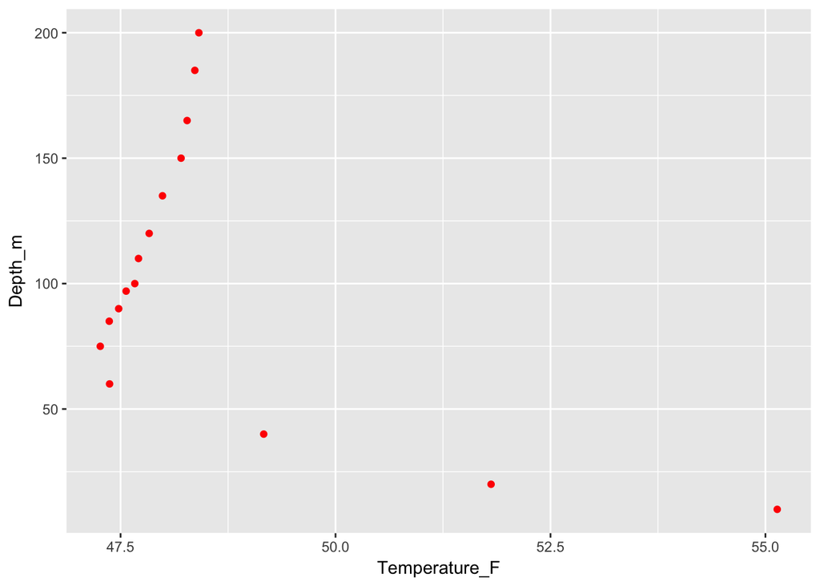

```r
exercise2 = select(Saanich_metadata, Temperature_C, Depth_m) %>%
  mutate(Temperature_F = (Temperature_C * (9/5)+32))

ggplot(exercise2, aes(x=Temperature_F, y=Depth_m)) +
  geom_point(color="red")
```

### Exercise 3: Create a bar plot at a different taxonomic level with more descriptive x- and y-axis labels as well as a title. Use the ggplot cheatsheet to learn the guides needed to change these labels.

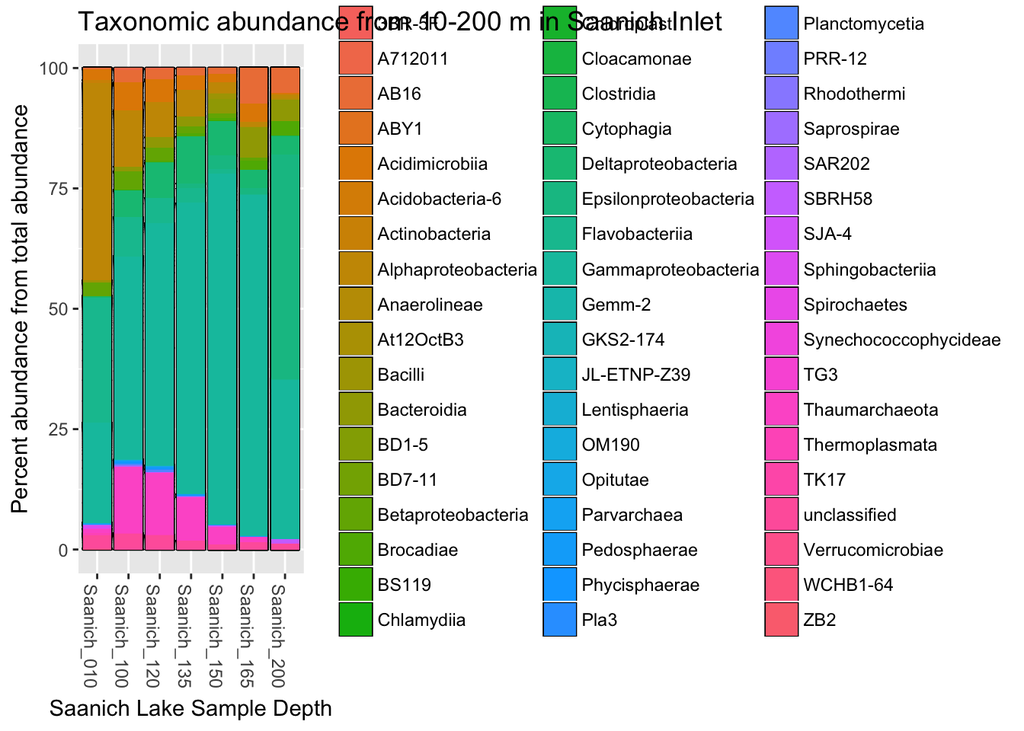

```r
load("phyloseq_object.RData")
physeq_percent = transform_sample_counts(physeq, function(x) 100 * x/sum(x))
plot_bar(physeq_percent, fill="Class") +
    geom_bar(aes(fill=Class), stat="identity") +
  ggtitle("Taxonomic abundance from 10-200 m in Saanich Inlet") +
  xlab("Saanich Lake Sample Depth") +
  ylab("Percent abundance from total abundance")
```

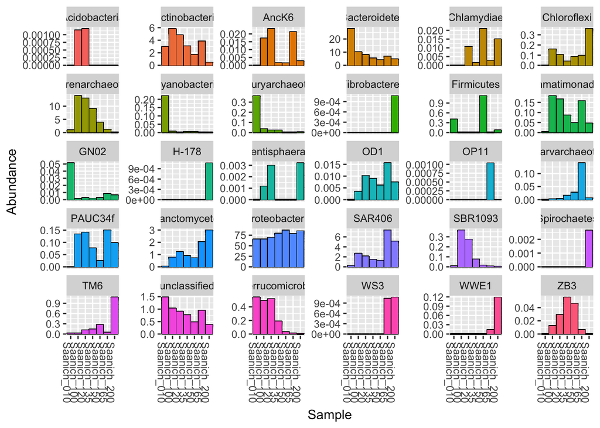

```r
plot_bar(physeq_percent, fill="Phylum") +
  geom_bar(aes(fill=Phylum), stat="identity") +
  facet_wrap(~Phylum, scales="free_y") +
  theme(legend.position="none")
```

### Exercise 4: Using ggplot, create a faceted figure showing nutrient concentrations in nM for O2, PO4, SiO2, NO3, NH4, and NO2 by depth. For this, you can use either the metadata table or the phyloseq object.

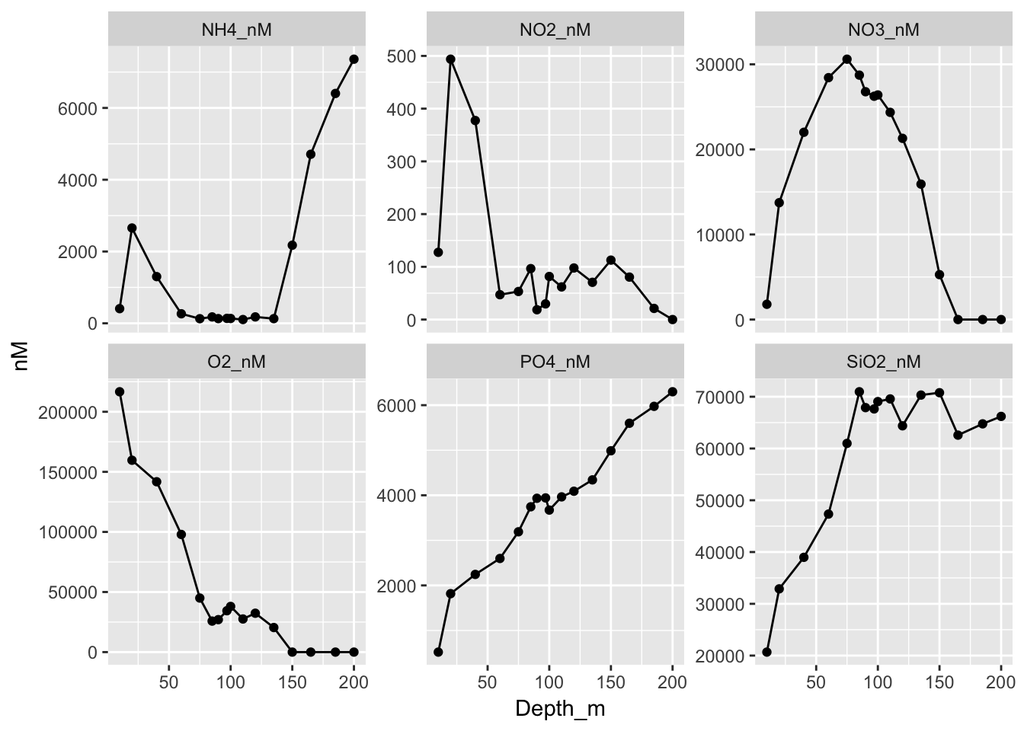

```r
exercise4 = select(Saanich_metadata, ends_with("uM"), Depth_m) %>%
  mutate(NH4_nM = NH4_uM*1000) %>%
  mutate(NO2_nM = NO2_uM*1000) %>%
  mutate(NO3_nM = NO3_uM*1000) %>%
  mutate(O2_nM = O2_uM*1000) %>%
  mutate(PO4_nM = PO4_uM*1000) %>%
  mutate(SiO2_nM = SiO2_uM*1000)

# Update: Concentrations were listed for "nM" in the assignment page, but later corrected to "uM". Exercise 4 was completed using the original instructions in "nM"

faceted = gather(exercise4, key = "Nutrient", value = "nM", ends_with("nM"))

ggplot(faceted, aes(x=Depth_m, y=nM))+
  geom_line()+
  geom_point()+
  facet_wrap(~Nutrient, scales="free_y") +
  theme(legend.position="none")
```

## Evidence worksheet_03 “The Anthropocene”

#### Learning objectives:

- Evaluate human impacts on the ecology and biogeochemistry of Earth systems. General Questions:
- What were the main questions being asked?

(Answer): Rockstrom et al. focused on identifying the various limits of each global ecological “boundaries” and how far humans have come to those boundaries. These boundaries includes climate change (atmopheric greenhouse gas), biodiversity loss (rate), nitrogen cycle (artificial fixation), phosphorous cycle (P flowing into ocean), stratospheric ozone depletion, ocean acidification, global freshwater use, land use, and atmospheric/chemical pollution.

- What were the primary methodological approaches used?

(Answer): Aggregate data based on multiple studies for each individual category was used to propose the boudnary level. The estimations were made conservatively, using rise-adverse approach. For example, greenhouse gas limit was estimated using atmospheric concentration and radiative forcing (rate of energy change per unit area). Other areas are estimated using comparisons of modern day measurements to historical fossil records to determine human impact.

- Summarize the main results or findings.

(Answer): Proposed Boundaries Climate change: 350 parts per million by volume Biodiversity loss: 10 per million species per year Nitrogen cycle: 35 millions of tonnes N2 per year removed from atmosphere Phosphorus cycle: 11 millions of tonnes per year P flowing into ocean Stratospheric ozone depletion: 276 Dobson unit Ocean Acidification: 2.75 Global mean saturation state of argonite in surface sea water Global freshwater use: 4000 km^3 per year Change in land use: 15 Percent of global land cover used as cropland Atmospheric arosol loading + Chemical polution: TBD

- Do new questions arise from the results?

(Answer): What is a “conservative estimate”? The paper does not indicate how the balance points are determined based on a consequence threshhold. The paper is limited in their approach to demonstrate what impacts of their proposed boundaries versus other proposed boundaries that exist in literature, and fail to demonstrate why theirs is methodologically more robust.

- Were there any specific challenges or advantages in understanding the paper (e.g. did the authors provide sufficient background information to understand experimental logic, were methods explained adequately, were any specific assumptions made, were conclusions justified based on the evidence, were the figures or tables useful and easy to understand)?

(Answer): The Estimation methods were not greatly elaborated, rather their determination of the arbitrary threshhold, although based on aggregate metadata, does not show how the environment shifts in response to these boundaries, and why we should care about their proposed boundaries versus others.

## Writing Assignment 1

Prompt: “Microbial life can easily live without us; we, however, cannot survive without the global catalysis and environmental transformations it provides”

Microbes have existed on Earth for eons, about 4 if one were to count. Their diverse evolutionary history is intimately intertwined with teraformation of the planet and its atmosphere, as well as its co-evolutionary relationship with most multicellular vertebrates that have, and will ever exist. The role of microbial life on the thriving flora and fauna of today is immense, but often overshadowed and overlooked by their larger and multicellular counterparts. At least in the eyes of the human conservationalists of today. Through the emergence of advanced molecular genetics techniques (such as genetic engineering and sequencing) and computational biology (bioinformatics) of recent times, humans have collectively just begun to realize (relative to anthropogenic time), and appreciate the biogeochemical role which microbes play to shape our world to be just the way it is. We have now uncovered evidence of early prokaryotic organisms harboring the genes and gene transfer mechanisms to serve as Earth’s Noah’s Ark, through mass extinctions and global biodiversity shifts in history [1].

Early evidence of horizontal gene transfer and our models of the emergent genes [1], we see that much of the metabolic and catalytic properties of microbes have been passed on from ancestors to descendants, from a time where the global metabolism is very different than they are today, yet these processes appear to be conserved. Relating that to the great oxygenation events of eons past, a clear trend comes into focus. Microbes shaped our planet; through their ability to carry out global catalysis of environmental nutrients/wastes in scales never thought possible. Figuratively speaking, they are ecologically “omnipotent”, existing in abundances that far outstrip all other living organisms combined. And they are omnipresent, rapidly evolving and filling ecological niches (physical or metabolic) nearly as quickly as they emerge. With rapid mutations and gene transfer capabilities, they are resilient, impossible to wipe out in their entirety [1]. It is foolish and hubris to believe, in any relevant capacity, that any form of intelligent life on Earth can come close to replacing the metabolic roles currently occupied by the microbes, and equally hubris to assume that life on Earth can exist without them.

But as much as microbes possess qualities that can only be anthropologically compared to gods and deities, microbes need us. They need humans, perhaps now more than ever before; perhaps as much as we need them. Ecologically speaking, times are changing. With humans rapidly industrializing by the minute; evidence shows that humans have significantly altered the Earth’s delicate biogeochemical cycles, such as the nitrogen and carbon cycle, in ways that can no longer be balanced by microbes in their current state [4]. Humans have accomplished this through a timeframe that is ecologically unheard of, and is doing so exponentially. This has been demonstrated to have caused severe, quantifiable, and irreversible biodiversity loss [4]. Simple as it is to substantiate the claim, “humans are unable to survive without the environmental transformation microbes provide”, the reverse is true for the subsequent claim: “Microbial life can easily live without us”, in the status quo.

Microbial life’s greatest strength is largely warranted by its sheer magnitude/abundance to which they can exist. Whitman et al. estimates in “Prokaryotes: the unseen majority” there are 4-6 x 1030 prokaryotic organisms dispersed among general environmental groups: marine, soil, subsurface, and microbiota environments [3]; and their respective carbon cycle participation is anywhere between matching to doubling that of plants and animals [3]. Their total role as nitrogen cycle and phosphorous cycle reservoirs is estimated to be about 10-folds greater than all other living organisms [3]. The massive scale which prokaryotic metabolism operates affords relative stability to perturbations from the environment. “Microbial engines” as modeled by Falkowski and colleagues [1], are relatively robust. However, as with any intricate system, significant shifts or adjustments will destabilize the tightly coevolved microbial engine. Rockstrom argues that modern industrial agricultural processes such as the synthetic fixation of gaseous nitrogen to reduced forms in fertilizer, is causing a multiple-fold increase in nitrogen fixation in the environment, causing destabilization of large marine-environments (eutrophication, anoxia) beyond the ability for the environment to re-stabilize [2]. Rockstrom et al. and Canfield et al. both observed that the amount of industrially fixed nitrogen more than matches all terrestrial processes, contributing significantly to global greenhouse gas emissions, pushing for the formation of nitrous oxide (a potent greenhouse gas), through ecological processes not unlike Le Chatelier’s principle [3, 4]. The phosphorous cycle has experienced a similar phenomenon, where Earth’s natural sediment reservoir is being uplifted by human industry and fed back into the biological phosphorous cycle; that if continued, will lead to anoxia in seas and oceans [3]. Ultimately, long term destabilization of ecological systems will result in large-scale environmental shifts if not corrected for, an extension of the climate change we observe today.

Keen proponents of microbial ecosystem resilience, to artificial influence, would be quick to remark upon the unique prokaryotic capabilities for rapid genetic modification, through the means of direct genetic mutation as well as horizontal gene transfer. Falkowski et al. indeed characterizes the relationship between environmental processes and the microbial genome as a metaphorical “microbial engine”. Falkowski et al. describes, based on molecular evidence (gene order and metabolic distribution), that much of today’s biogeochemical cycles emerged from evolutionary time, through the means of horizontal propagation, which lead to a wide distribution of metabolic genes between events of cellular differentiation [1, 7]. Today we can observe a wide taxonomic range of organisms favoring the sharing of an increasingly conserved pool of global metabolic genes, over the evolution of brand new genes with no known homologs, or at least the ones we know to exist [Falkowski et al, 2008: fig. 3]. The concept of “Microbes as guardians of metabolism” does not describe rapid genetic modifications as a mechanism for increasing short term fitness, but rather for long term evolutionary survival on a population scale. Population genomics through horizontal gene transfer is no doubt capable of maintaining key metabolic machinery in long term within select organisms, much like a Noah’s Ark as an analogy. However, little evidence exists to show that these genetic modulation mechanisms are capable of halting/slowing down biodiversity loss as due to a shift in selection pressure. Even with consideration of the “Microbes as guardians of metabolism” concept, the collective consensus within the scientific community points to the ultimate loss of much of Earth’s microbial diversity seen in the status quo with respect to anthropogenic climate change.

Earth’s evolutionary history operates in an entirely different timeframe than our anthropogenic history. While the human legacy spans a respectable 200,000 years since the homo sapiens species origin, microbial life has been shaping the fate of Earth since approximately 4 billion years ago. Through this time, numerous rapid environmental changes occurred, which resulted in emergence of new eras of global microbial ecosystems characterized by their impact on the biogeochemical properties of the planet. Using oxygenation of the atmosphere as an example of evolutionary timeframes, Nisbet and Sleep describes early microbial history to be “bottlenecked” by the relative inhospitable conditions that would rapidly arise. Nisbet and Sleep attributes early bottlenecks of life to the relatively low sunlight followed by volcanic and extraterrestrial bombardments [5]. The emergence of oxygenation from the carbon dioxide and ammonium rich early Earth atmosphere had only been accomplished through the evolution of several layers of increasingly specialized phototrophic microorganisms over the course of eons [4, 5], both prokaryotic and eventually eukaryotic. The primary engine component attributed to for the oxygenation of Earth’s atmospheric oxygen composition is the emergence of cyanobacteria. In its current form, it’s emergence was characterized to 2.3 billion years ago, nearly two eons prior to the first emergence of phototrophy [6]. From that point, numerous eras furthered the atmospheric oxygenation needed to sustain vertebrate life. It is safe to say; the Earth will not be repeating the biogeochemical timeframes it once took to deliver humans the world which we live on today.

For better or for worse, humans have dramatically altered the world in the course of a mere handful of milliseconds following the evolutionary clock analogy. Chris Mooney from the Washington Post article titled: “Scientists say humans have now brought on an entirely new geologic epoch”, claims that the combination of atmospheric modulation and sedimentary disturbances followed by widespread flora and fauna disruption, from human industrial activity, has left enough of impact to become detected in geological history. This warrants the ushering of the “Anthropocene” the era of humans. As evident by the stark contrast in timeframes which the Earth’s microbial engines operates versus humans, the question no longer remains whether microbial engines are capable of driving the planet forward in a manner that sustains our large planetary biodiversity, microbial or otherwise. The new question emerges, whether humans have any role to play in this new global paradigm.

Continuing with the train of metaphors, Joel Achenbach from the Washington Post article titled: “Spaceship Earth: A new view of metaphors” portrays our planetary metabolic network as a “Spacehship Earth, enter[ing] 2012 belching smoke, overheating and burning through fuel at a frightening rate. It’s feeling pretty crowded, and the crew is mutinous. No one’s at the helm”. Summarizing the reality at hand; humans, through industrialization, has pushed our environmental metabolic network beyond its limits for destabilization; warranted by the introduction of industrially fixed nitrogen and overturned sedimentary phosphorous species among many more. Ultimately resulting in a change in selection pressure, that leads to the shift of ecological conditions away from the status quo and cements a future that is less habitable by the world’s current biodiversity.

While it is true that microbial life, through horizontal gene transfers, exhibits high metabolic resiliency on the community level, individuals and entire species are put at risk due to environmental metabolic shifting. Microbial metabolic potential will carry on in small populations of microorganisms (Noah’s Ark analogy), but the vast majority of biodiversity will become extinguished in the event of ecological catastrophes. And the impact of this includes a reduced potential for Earth to sustain life, microbial, human, or otherwise, moving forward into the future.

Whether humans can survive on a planet without microbial catalysis, or whether metabolic potential within small fringe microbial communities can survive through a given human-induced ecological catastrophe, both are fruitless debates. In an ideal “Spaceship Earth”, there ought to be a captain, crew, and engines to keep it all going. Falkowski’s “Microbial engines” represents the baseline catalysis of metabolites by microbial genomic potential, but ultimately requires human intervention, a “captain at the helm” to offset evolutionary forces acting on a human destabilized ecosystem. Joel Achenbach outlines how the time for interventionist ecology is now, and that humans are in a better position technologically and logistically than ever before to offset the industrial metabolites that are being offloaded into the natural nutrient cycles [2, 4]. Humans are capable of renewable energy, biochemical/atmospheric engineering, and molecular genetics techniques all readily implementable to tackle the ecological damage in a directed and stepwise manner. Humans are becoming smarter, faster, and more just, at least according to Joel from “Spaceship Earth”. Socioeconomic infrastructure is developing alongside technological ones to promote sustainable growth, responsible development, and a more wholly encompassing worldview that spans beyond the human race. Maybe, just maybe, there can exist a future where intelligent life co-exists with microbial catalysis on the global scale that promotes symbiosis between mother nature, and sentient industriousness.

References:

1. Falkowski PG, Fenchel T, Delong EF. 2008. The Microbial Engines That Drive Earth’s Biological Cycles. Science 320:1034-1038.
2. Rocksrtrom J, et al. 2009. A safe operating space for humanity. Nature 461:472-475
3. Whitman WB, Coleman DC, Wiebe WJ. 1998. Prokaryotes: The unseen majority. Proc. Natl. Acad. Sci. 95:6578-6583.
4. Canfield DE, Glazer AN, Falkowski PG. 2010. The Evolution and Future of Earth’s Nitrogen Cycle. Science 330:192-196.
5. Nisbet EG, Sleep NH. 2001. The habitat and nature of early life. Nature 409:1083-1091.
6. Kasting JF, Siefert JL. 2003. Life and the Evolution of Earth’s Atmosphere. Science 296:1066-1067.
7. Falkowski PG et al. 2000. The Global Carbon Cycle. Science 290:291-296.

### Module 01 references

Utilize this space to include a bibliography of any literature you want associated with this module. We recommend keeping this as the final header under each module.

Whitman WB, Coleman DC, and Wiebe WJ. 1998. Prokaryotes: The unseen majority. Proc Natl Acad Sci USA. 95(12):6578–6583. [PMC33863](https://www.ncbi.nlm.nih.gov/pmc/articles/PMC33863/)

# Module 02

## Module 02 portfolio check

The first of your second level headers (##) is to be used for the portfolio content checks. The Module 01 portfolio check has been built for you directly into this template, but will also be available as a stand-alone markdown document available on the MICB425 GitHub so that you know what is required in each module section in your portfolio. The completion status and comments will be filled in by the instructors during portfolio checks when your current portfolios are pulled from GitHub.

- Evidence worksheet_04
  - Completion status:
  - Comments:
- Problem Set_03
  - Completion status:
  - Comments:
- Additional Readings
  - Completion status:
  - Comments

### Evidence Worksheet_04

### Learning objectives:

- Discuss the relationship between microbial community structure and metabolic diversity
- Evaluate common methods for studying the diversity of microbial communities
- Recognize basic design elements in metagenomic workflows

### General Questions:

- What were the main questions being asked?

(Answer): To understand to a greater genetics and biochemical degree regarding the functional capacity of proteorhodopsins and their effects on the microbial metabolic potential and their ability to enhance growth when transferred via HGT.

- What were the primary methodological approaches used?

(Answer): Functional screening through large insertion library of clones expressing PR photosystems. Transposon mutants were analyzed for biochemical products of the PR genes. Heterologous expression experiments were used to show that the PR genes can be aquired through HGT and that phototrophy is a transient property.

- Summarize the main results or findings.

(Answer): Functional screens of metagenomic libraries without cloning was able to achieve higher levels of recombinant gene expression into detectable phenotypes. Using these methods, they identified and developed a method to demonstrate that PR genes can be transferred and heterologously expressed, while to an extent that can substantially alter the growth rates of organisms that uptake this system.

- Do new questions arise from the results?

(Answer): How do bacteria gather these genes and transfer them in reality? (AKA, not in a controlled test environment where the mechanism is determined as a manipulated variable)? Is there evidence of enhanced growth in PR capable species in nature by such things as abundance measurements in recovered sequencing reads?

- Were there any specific challenges or advantages in understanding the paper (e.g. did the authors provide sufficient background information to understand experimental logic, were methods explained adequately, were any specific assumptions made, were conclusions justified based on the evidence, were the figures or tables useful and easy to understand)?

(Answer): One of the biggest assumptions made is that ATP synthesis was measured as a proxy for the growth rates. It is unclear/incomplete that the author is using a proxy for growth rather than measuring the growth exactly. Building more ATP does not represent a true measure for growth since having more temporary energy sources does not necessarily dictate the growth of an organism in the actual environment.

## Problem set_03 “Metagenomics: Genomic Analysis of Microbial Communities”

#### Learning objectives:

Specific emphasis should be placed on the process used to find the answer. Be as comprehensive as possible e.g. provide URLs for web sources, literature citations, etc.  
*(Reminders for how to format links, etc in RMarkdown are in the RMarkdown Cheat Sheets)*

#### Specific Questions:

- How many prokaryotic divisions have been described and how many have no cultured representatives (microbial dark matter)?

(Answer): As of 2003, 26 of the 52 major bacterial phyla have been cultured, only about 50%. The estimate is far fewer now, with more uncultured species being discovered. In 2016, only 89 bactetial phyla and 20 archeal phyla (examined via the 16s rRNA databases). All of this amounts to approximately 1% of microbes in a given ecological niche is cultivatable.

- How many metagenome sequencing projects are currently available in the public domain and what types of environments are they sourced from?

(Answer): Thousands are available in the public domain, sourcing from a wide range of environments from marine to soil environments. With microbiota, marine, sediments, and aquatic being some of the more prevalent environments. These projects shed light on difficult to culture/uncultured organisms from those environments.

- What types of on-line resources are available for warehousing and/or analyzing environmental sequence information (provide names, URLS and applications)?

(Answer): Oulas, Anastasis, et al. 2015. Metagenomics: Tools and insights for analyzing next-generation sequencing data derived from biodiversity studies. Bioinformatics and biology insights 9:BBI-S12462.

Siegwald, Lea, et al. 2017. Assessment of common and emerging bioinformatics pipelines for targeted metagenomics. PLoS One 12.1:e0169563.

Assembly: Euler, MEGAHIT, VELVET Binning: MaxBin, S-GCOM Annotation: KEGG, COG, Metacyc, SILVA Analysis Pipelines: Megan5 Standalone Software: OTUbase Denoising: AmpliconNoise Databses: Ribosomal Database Project, Refseq, SILVA

- What is the difference between phylogenetic and functional gene anchors and how can they be used in metagenome analysis?

(Answer): Phylogenetic gene anchors differ from functional ones in that phylogenetic anchors represent conserved regions of essential genes that can be a base of comparison between most/all organsims. Such genes do not undergo divergent mutations due to their necessity in sustaining biological life. Functional gene anchors are a base of comparison not between organisms themselves, but between functions and metabolic steps that is investigated. Will show the convergence/divergence of a metabolic process as a whole rather than the composition of the community within.

- What is metagenomic sequence binning? What types of algorithmic approaches are used to produce sequence bins? What are some risks and opportunities associated with using sequence bins for metabolic reconstruction of uncultivated microorganisms?

(Answer): Binning is the process of grouping sequences in the aim of reconstructing the genome of a single organism from a large set of genome data. Algorithm: 1. Align sequence to database (guided binning) 2. Grouping based on DNA characteristics such as GC content (denovo) Risks: Incomplete coverage of the genome sequence (very likely), or contamination from different phylogeny.

- Is there an alternative to metagenomic shotgun sequencing that can be used to access the metabolic potential of uncultivated microorganisms? What are some risks and opportunities associated with this alternative?

(Answer): Single cell genomics through cell sorting (with FACs or the likes), and reconstructing the genomes of single cells is the emerging field that contrasts with WGS. The advantages is that single cell genomes are much less likely to suffer from high phylogenetic contamination, but due to the sampling method (sampling bias), the coverage of the genome may not be very good, yielding low completeness.

# Module 03

## Module 03 Portfolio Content

- Evidence worksheet_05
  - Completion status:
  - Comments:
- Problem set_04
  - Completion status:
  - Comments:
- Writing Assessment_03
  - Completion status:
  - Comments:
- Project_1
  - Completion status:
  - Comments:

## Problem set_04 “Fine-scale phylogenetic architecture”

#### Learning objectives:

- Gain experience estimating diversity within a hypothetical microbial community

#### Part 1: Description and enumeration

Obtain a collection of “microbial” cells from “seawater”. The cells were concentrated from different depth intervals by a marine microbiologist travelling along the Line-P transect in the northeast subarctic Pacific Ocean off the coast of Vancouver Island British Columbia.

Sort out and identify different microbial “species” based on shared properties or traits. Record your data in this Rmarkdown using the example data as a guide.

Once you have defined your binning criteria, separate the cells using the sampling bags provided. These operational taxonomic units (OTUs) will be considered separate “species”. This problem set is based on content available at [What is Biodiversity](http://cnx.org/content/m12179/latest/).

For example, load in the packages you will use.

```r
#To make tables
library(kableExtra)
library(knitr)
#To manipulate and plot data
library(tidyverse)
```

Then load in the data. You should use a similar format to record your community data.

```r
example_data1 = data.frame(
  number = c(1,2,3),
  name = c("lion", "tiger", "bear"),
  characteristics = c("brown cat", "striped cat", "not a cat"),
  occurences = c(2, 4, 1)
)
```

Finally, use these data to create a table.

```r
example_data1 %>%
  kable("html") %>%
  kable_styling(bootstrap_options = "striped", font_size = 10, full_width = F)
```

| number | name | characteristics | occurences |
| --- | --- | --- | --- |
| 1 | lion | brown cat | 2 |
| 2 | tiger | striped cat | 4 |
| 3 | bear | not a cat | 1 |

For your sample:

- Construct a table listing each species, its distinguishing characteristics, the name you have given it, and the number of occurrences of the species in the collection.
- Ask yourself if your collection of microbial cells from seawater represents the actual diversity of microorganisms inhabiting waters along the Line-P transect. Were the majority of different species sampled or were many missed?

```r
candy_counts = read.table(file="Candy_counts.csv", header=TRUE, sep=",", na.strings=c("NAN", "NA", "."))
candy_table = candy_counts %>% kable("html")

# The collection of microbial cells from seawater missed many species, especially if they were already in low abundance.
```

[output not shown]